# CWRU DSCI353-353M-453: 02b Intro to LinRegr-ISLR2

Profs: R. H. French, L. S. Bruckman, P. Leu, K. Davis, S. Cirlos

TAs: W. Oltjen, K. Hernandez, M. Li, M. Li, D. Colvin

31 January, 2023

License: [CC-BY-SA 4.0](https://creativecommons.org/licenses/by-sa/4.0/)

#### Class Readings, Assignments, Syllabus Topics

##### Textbooks

- Introduction to R and Data Science
  - For R, Coding, Inferential Statistics
    - Peng: R Programming for Data Science
    - Peng: Exploratory Data Analysis with R

Textbooks for this class

- OIS = Diez, Barr, Çetinkaya-Runde: Open Intro Stat v4
- R4DS = Wickham, Grolemund: R for Data Science

Textbooks for DSCI353/353M/453, And in your Repo now

- ISLR = James, Witten, Hastie, Tibshirani: Intro to Statistical Learning with R
- ESL = Trevor Hastie, Tibshirani, Friedman: Elements of Statistical Learning
- DLwR = Chollet, Allaire: Deep Learning with R

Magazine Articles about Deep Learning

- DL1 to DL6 are “Deep Learning” articles in 3-readings/2-articles/

#### Syllabus

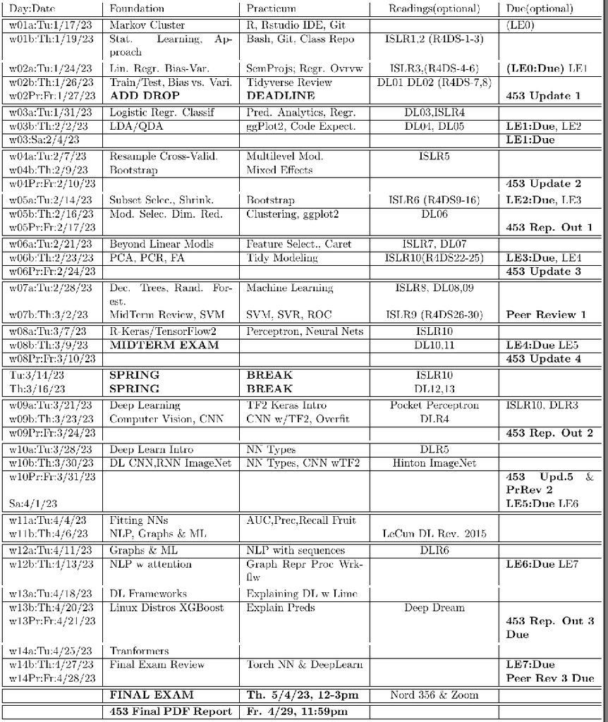

Modeling, Prediction and Machine Learning Syllabus

##### Tidyverse Cheatsheets, Functions and Reading Your Code

- Look at the Tidyverse Cheatsheet
  - **Tidyverse For Beginners Cheatsheet**
    - In the Git/20s-dsci353-353m-453-prof/3-readings/3-CheatSheets/ folder
  - **Data Wrangling with dplyr and tidyr Cheatsheet**

  Tidyverse Functions & Conventions
  - The pipe operator `%>%`
  - Use `dplyr::filter()` to subset data row-wise.
  - Use `dplyr::arrange()` to sort the observations in a data frame
  - Use `dplyr::mutate()` to update or create new columns of a data frame
  - Use `dplyr::summarize()` to turn many observations into a single data point
  - Use `dplyr::arrange()` to change the ordering of the rows of a data frame
  - Use `dplyr::select()` to choose variables from a tibble,
    - keeps only variables you mention
  - Use `dplyr::rename()` keeps all the variables and renames variables
    - rename(iris, petal_length = Petal.Length)
  - These can be combined using `dplyr::group_by()`
    - which lets you perform operations “by group”.
  - The `%in%` matches conditions provided by a vector using the c() function
  - The **forcats** package has tidyverse functions
    - for factors (categorical variables)
  - The **readr** package has tidyverse functions
    - to read_…, melt_… col_…, parse_… data and objects

Reading Your Code: Whenever you see

- The assignment operator `<-`, think **“gets”**
- The pipe operator, `%>%`, think **“then”**

#### ISLR Chapter 2 Regression and IntroR Lab Excerise

- From Hastie and Tibshirani
  - They have good notation
  - And a good intro to R

##### Regression is the case of supervised learning

- Where we have a quantitative response
  - that is associated with the predictors
  - And we want to develop a predictive model
    - that relates predictors with response

#### Function Notation for a Predictive model

- Some notation for predictive models
  - Response $Y$ which we want to predict
  - And the Predictors we will use are $\textbf{X}=X{_1}+X{_2}+X{_3}$
    - when we have $P$ number of predictors,
      - and $P=3$ in this example
    - where the predictors $\textbf{X}$ is a vector
    - And $\textbf{X}$ is a column vector containing $(X{_1},X{_2},X{_3})$
    - Which has 3 components $X{_1}+X{_2}+X{_3}$
    - We also have to have an error term $\epsilon$
  - Our predictive model will then be
    - $Y = f(\textbf{X}) + \epsilon$
  - $\epsilon$ error term is a catch all
    - captures measurement error, and other discrepancies
    - we can never model something perfectly
  - And for the predictor $\textbf{X}$
    - A single instance of $X$ is $x$
    - i.e. $(x{_1},x{_2},x{_3})$
    - three specific values of the 3 components
    - of 1 individual observation, i.e. $x$
    - of the predictor $X$

##### Variables

- Independent Variables $\textbf{X}$ are called
  - independent variables
  - predictors
  - exogenous variables
  - features (this is general CS term)
- Dependent Variables $\textbf{Y}$ are called
  - dependent variables
  - responses
  - endogenous variables

In some cases, such as network models

- Some variables may be both.
  - independent, predictors
  - and also dependent response
- Such as in our group’s netSEM structural equation models
  - take a look at SEM package

```r
# install.packages("sem")
library(sem)
help(sem)


# install.packages("lavaan")
library(lavaan)
help(lavaan)

# install.packages("netSEM")
library(netSEM)
help(netSEM)
```

##### Expected Values of a Predictive Model

- Now, once you have a predictive model

How well does it do, fitting your actual response?

- Remember a function is by definition single-valued
  - for a given value $x{_1}$ of the independent variable X
  - there is only dependent value $y{_1}$ for the dependent variable Y
- Therefore it can never actually predict
  - the exact observed value of the response
- this is why we keep the error term $\epsilon$ explicit

The Expected Value of a Regression Function

- Our regression function is $Y=f(\textbf{X})+\epsilon$
- Gives the Expected value of the response for $X=4$

Notation for this is:

$$f(4)=E(Y|X=4)$$

Or for our vector $\textbf{X}$

$$f(x) = f(x{_1}, x{_2}, x{_3}) = E(Y
|X{_1} = x{_1}, X{_2} = x{_2}, X{_3} = x{_3})$$

##### The ideal or optimal predictor of Y

- Minimizes the **loss function**
  - between the function and the data
- For example minimizing the sum of squared errors

##### An estimate (one version) of $f(X)$

- is called $\hat{f}(X)$
- since we could determine many versions of $f(X)$

And then we’ll determine the best one of these $\hat{f}(X)$ functions

- That reduces the loss function

##### And then we are left with the irreducible error

- Which is just the variance of the errors.

##### So by better model building

- we can reduce the reducible error
- and we’re left with the irreducible error.
  - Which I think of as the true “noise” in the data

#### Overview of the Regression Function and its nature

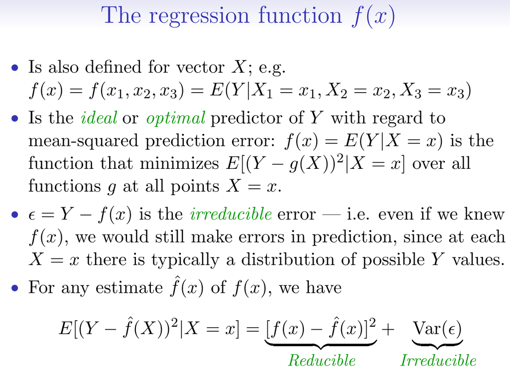

the regression function and its nature

##### How do we estimate the function $f(X)$?

- We can perform the loss function minimization, at each specific value $x$ of $X$.
  - Or at least in the neighborhood of $x$,
    - which is denoted by $\mathcal{N}(x)$
    - and called Nearest Neighbor Averaging

Note that the regression function $f(X)$ is not an algebraic function

- We didn’t guesstimate it should be quadratic or some such.
- It is a numerical function defined for each value $x$ of $X$

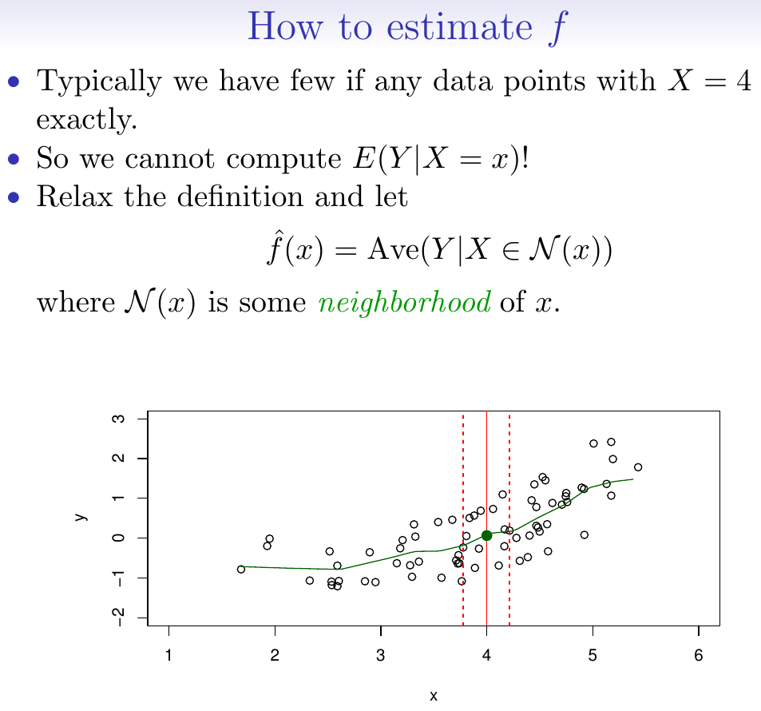

how to determine the regression function $f(X)$

#### The Curse of Dimensionality

- When we are doing our nearest neighborhood averaging
  - in high dimensional datasets
  - we are hit by the curse of dimensionality
    - We can’t define who are nearest neighbors
    - Because they tend to be far away in high dimensions

This hits us in many places of Prediction, Modeling and Statistical Learning

- [The Curse of Dimensionality](https://en.wikipedia.org/wiki/Curse_of_dimensionality)

#### Parametric and Structured Models

- One way to get around the curse of dimensionality,
  - Use Parametric Models

$$f_{l}(X)=\beta_{0}+\beta_{1}X_{1}+\beta_{2}X_{2}+...\beta_{p}X_{p}$$

Where there are $p+1$ parameters in the model

- Which are estimated by fitting the model to the data

Estimated values of a parameter $\beta$

- are denoted as $\hat{\beta}$

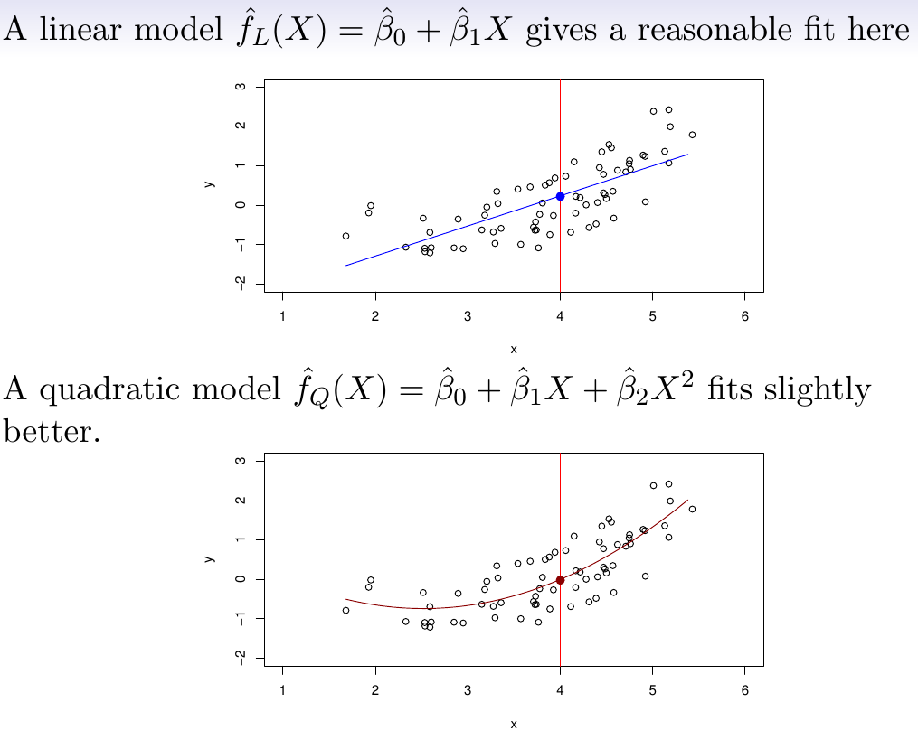

Examples of Parametric Models

##### Some tradeoffs in regression modeling

- Prediction accuracy versus interpretability.
  - Linear models are easy to interpret;
  - thin-plate splines are not.
- Good fit versus over-fit or under-fit.
  - How do we know when the fit is just right?
- Parsimony versus black-box.
  - We often prefer a simpler model
    - involving fewer variables
  - Over a black-box predictor
    - involving them all.

##### Interpretability vs Flexibility

- Here are some of the approaches we’ll look at this semester
  - Simpler models could be more interpretable
    - Or could be too naive
  - Flexibility makes for good fits
    - But can lead to overfitting

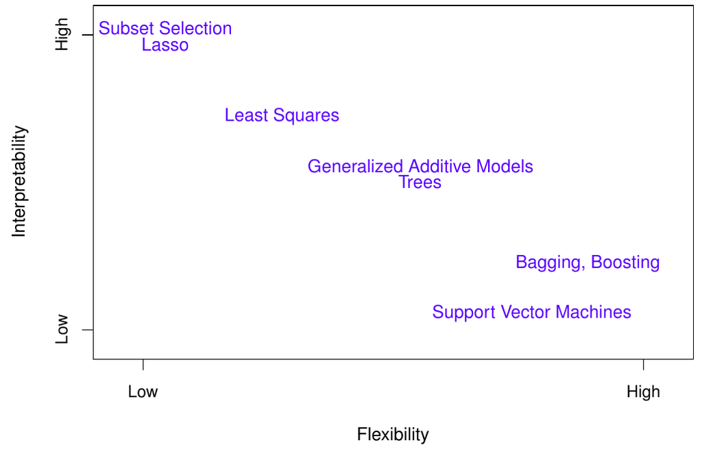

Interpretability vs Flexibility

#### Assessing Model Accuracy

##### Have to use training (Tr) and testing (Te) datasets

- To determine the best predictive model

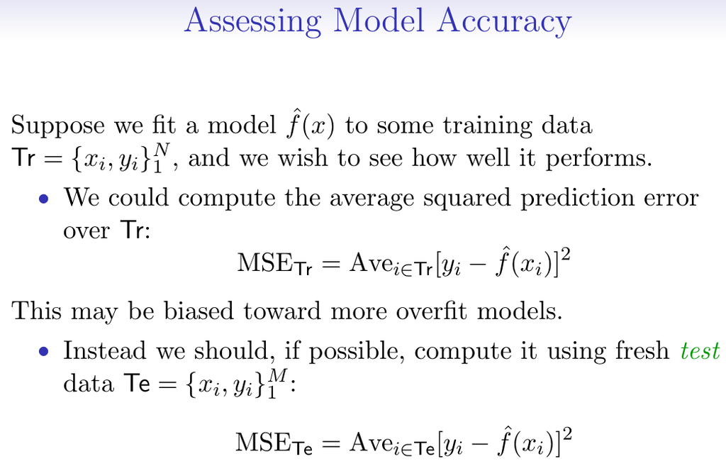

Assessing Model Accuracy

#### The Bias vs. Variance Trade-off

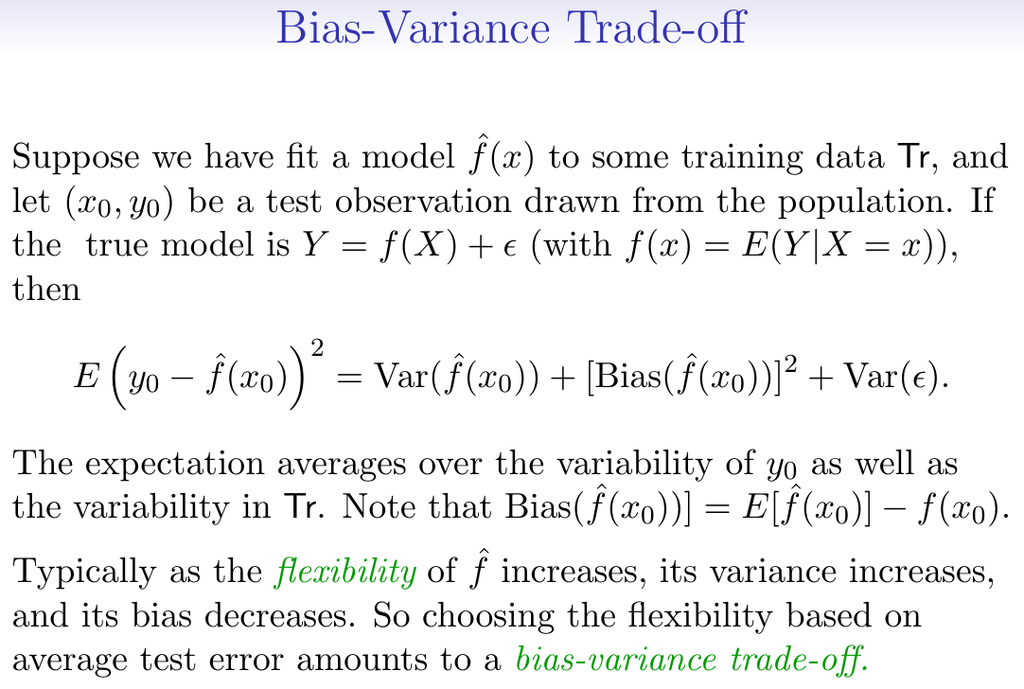

Bias vs. Variance Trade-off

- The hat is the estimated value of something. $\hat{f}(X)$
- We can see the variance of $\hat{f}(X)$
- And the bias in $\hat{f}(X)$

Choosing the flexibility of your fitting function

- (i.e the number of predictors, or coefficients, in your model function)
- based on average test error
- amounts to what we call a bias-variance trade-off

And we use training datasets and testing datasets

- which we apply our model to
- to determine the optimal tradeoff we should use
- for a specific problem and model

[figure not shown]

Bias vs. Variance in a Training & Testing Framework

##### How does all this play out in Classification Problems

- As opposed to Regression Problems, which we just discussed

#### Citations

- R Core Team. R: A Language and Environment for Statistical Computing. Vienna, Austria: [R Foundation for Statistical Computing, 2014.](http://www.R-project.org/).
- G. James, D. Witten, T. Hastie, and R. Tibshirani, An Introduction to Statistical Learning: 2nd Ed., with Applications in R, 2nd ed. 2021 edition. New York: Springer, 2021.
- Abbass Al Sharif. “Applied Modern Statistical Learning Techniques.” [Abbass-Al-Sharif. Accessed January 17, 2016.(http://www.alsharif.info/).
- Diez, David M., Christopher D. Barr, and Mine Çetinkaya-Rundel. OpenIntro Statistics: Third Edition. 3 edition. S.l.: OpenIntro, Inc., 2015.
- Mayor, Eric. Learning Predictive Analytics with R. Packt Publishing - ebooks, 2015.